# An Overview of Business Intelligence

## What is Business Intelligence?

At a high level, business intelligence is the collection, analysis, and presentation of business information usually with the purpose of improving and informing decision making. Business intelligence involves the collection of operational data from different parts of an organization, such as marketing, HR, and sales, in a single data repository which can be used to provide a higher-level analysis than any one department could do on their own. In addition to internal data, business intelligence teams can also use external data to analyze market trends or compare a company’s performance against similar companies in the same industry. BI can be used to analyze past performance, determine how well an organization is currently doing, or make future projections. Ultimately, the goal of BI is to transform data into meaningful information that can be used to guide users in their decision-making process.

## What can BI do? How can BI help?

By analyzing data, BI can provide useful, actionable information to an organization. For example, when developing a new product, a company might be interested in purchasing trends for similar products. After releasing the product, the company can analyze posts on social media for feedback. The company could make use of demographic data to efficiently market to consumers who are most likely to buy the product. By analyzing production and distribution data, the company could lower costs.

BI can also provide valuable information for internal decision making. BI could be used to analyze resource utilization - helping to determine if additional resources are required or if current resources need to be upgraded. BI can aid HR to determine how compensation and benefits offerings affects hiring and employee retention. BI can be used to optimize an organization's website - analyzing the typical flow of traffic through various pages and optimizing the site for a better customer experience.

BI can also augment existing data-gather and reporting activities within an organization. A finance might be tasked with regularly reporting financial information - BI can not only aid in report generation but develop visualizations and dashboards that provide management with current financial information. BI can be used to aid in real-time fraud detection by analyzing data and detecting defined trends.

In general, there is a broad range of applications for BI.

## What are some real-world examples?

In 1993, gambling on Indian reservations and riverboats was legalized. Owners of existing casinos wanted to take advantage of this to expand into new markets. To successfully expand, new casinos would need to attract and retain new customers. At the time, companies owning casinos had marketing strategies geared toward each casino promoting itself. Further, these companies invested in in-casino malls and similar attractions to draw customers. While this was successful in bringing customers into the casino, the cost to operate them significantly reduced revenue generated by the casino itself.

Harrah's Entertainment, Inc. chose a different strategy: to focus on their brand. Rather than focus on each casino individually, Harrah's sought a company-wide approach to build brand loyalty. Rather than invest in attractions that would be costly to maintain, Harrah's instead sought to better understand their customers. By tracking customers across all their casinos, Harrah's could determine who their customers were, how often they gambled, how much they gambled, and what sort of offers would bring them to a casino. This allowed Harrah's to target specific groups of customers with specific offers resulting in increased profitability.

To achieve this, Harrah's invested a significant amount in its IT infrastructure and spent time redeveloping their marketing processes. With a new system in place and backed by data, Harrah's could test different marketing strategies - expanding those that were successful and improving those that underperformed.

Another example is Continental Airlines which, prior to its merger with United in 2012, earned several best-in-class awards between 2004 and 2010. In the 1990s, however, Continental was not doing well. Having gone through multiple bankruptcies and ten CEOs in a ten-year period, Continental launched a series of BI initiatives to improve their performance and position in the market.

To improve revenue, Continental implemented real-time tracking of fares and sales allowing them to immediately gain insight into the response to different fares and adjust the numbers of seats sold at a given fare accordingly - this led to an increase in revenue. Continental also began collecting more data on its customers and analyzing it more frequently - this allowed Continental to track high-value customers and reach out to those who might have experienced an unexpected disruption in travel. This improved customer's view of the airline. Dashboards were also developed to provide information about flight times and delays between airports - this allowed Continental to anticipate delays and react by allocating additional staff to expedite the flight services.

## Who works on a BI team?

Like any group of people, a BI team consists of people filling various roles each with different responsibilities. A BI team, like many groups within an organization, is led by a program manager who serves as a liaison between the team and the rest of the organization. The program manager works with upper management to determine the goals and direction of the BI team and helps manage expectations. The program manager also often serves as a BI advocate to the rest of the organization. Within the team, the program manager oversees BI projects to ensure they meet defined requirements and standards. For sufficiently large teams, project managers might assist with this responsibility.

Some members of the BI will spend a lot of time work with other groups within the organization. A business analyst works with end users to coordinate the types of services or products the BI team will provide. The business analyst helps determine the needs and users and formulate requirements as well as recommending solutions. Working with end users, the business analyst can identify new sources of data and gather feedback on work done by the BI team. A data analyst will often work with users to understand the data that's available - possibly pulling data from various sources and integrating it to provide meaningful answers to users' questions.

There are often several roles dedicated to managing data and provide reporting tools. A data architect A data architect typically designs and, to some extent, maintains the data repository. A data architect will work with the maintainers of source data to profile the data, determining the size and content of data. A data architect works closely with database administrators to ensure that the supporting infrastructure meets the team's needs. Adding data to the data repository is the primary responsibility of the Extract, Transform, and Load (ETL) developer. The ETL developer determines how source data will be collected and added to the BI data repository. The ETL developer will often need to transform data to make it consistent (e.g., ensuring all dates are of a certain format) or alter it to have the same structure as similar, existing data. A report developer or designer creates reports, visualizations, and dashboards used to provide information to users. For more complex analysis, a BI team might include a data scientist. The data scientist employs advanced mathematical techniques to analyze data and create predictive models.

## Can Agile be used with BI?

Absolutely. Adopting Agile principles with BI development can BI more successful within an organization. A common road-block to BI adoption within an organization is the time it takes to show value. With traditional development practices, a BI solution might be obsolete when it's made available to an end user or the user who initially requested a dashboard might have left the organization. A common criticism of BI teams is that they are very data-centric - often focused more on the data than the user.

Following an incremental and iterative approach to development with frequent user collaboration not only ensures that the BI team is able to respond to changing requirements but also provides value more quickly to users. Routine validation also avoids wasting time and resources on a solution that is unwanted or not useful. Being able to show value quickly, being able to respond to changing needs, and regularly responding to feedback ensure better user adoption of BI.

## What can go wrong?

While BI can potentially help make sense of data and better inform the decision-making process, there are several important factors, external to the BI team, that can determine whether BI is successful or not in an organization. A major factor is business need. If there is no perceived need by potential end users, there will be no demand for BI solutions (and no work for the BI team). Provided there is a business need, management support is critical. BI makes use of data from and provides insightful data to different parts of an organization; management support is required to ensure that different departments coordinate with the BI team. Further, management must ensure that a BI team has both resources and staff to complete its objectives. IT support is also critical to ensure there is sufficient and well-maintained infrastructure to support BI activities.

Data can also play a role in the success or failure of BI in an organization. Necessary data must be available to the BI team. Generally, management can ensure that the BI team has access to the required data. Beyond data availability, data quality is important. Data of poor quality can require a lot of effort to clean-up, possibly requiring more time than is feasible for a project with a near-term deadline. It is also possible that the existing data is insufficient and cannot be used to meet the needs of end users. With poor data quality, data collection must be improved before it can be used for analysis.

## An Example

In this example, we explore two datasets from [Kaggle](https://www.kaggle.com) to simulate a real-world application of BI to aid in decision-making within an organization. Here, we'll use an [IBM HR dataset](https://www.kaggle.com/pavansubhasht/ibm-hr-analytics-attrition-dataset) to simulate internal data and [another HR dataset](https://www.kaggle.com/ludobenistant/hr-analytics) to represent external data from similar companies.

### Requirements

In a meeting with an HR manager, the manager indicated that upper management was concerned about employee retention and asked how our company performed relative to similar companies in our industry. Similarly, management would like to know if there are indicators that we could use to improve retention.

After discussion with a BI project manager, the HR manager indicated that that the two things we'd like to know is how our company performs relative to others in the industry and if there were any indicators (from among the data we have) that indicate that an employee is likely to leave the company.

### Gathering Data

Typically, a process of regularly importing data from the HR database would be put in place for the BI team to access up-to-date data. For this example, we'll work with a file that represents data at a specific point in time.

To be able to compare our company's attrition rates against the industries, a data set might be purchased from a third party.

```python
# prepare the environment for working with data
%matplotlib inline
import pandas as pd
import matplotlib.pyplot as plt
from IPython.core.display import display

pd.set_option('max_columns', 100)
```

```python
# load data files
internal = pd.read_csv('internal.csv')
industry = pd.read_csv('industry.csv')
```

### Processing and Cleaning

New data often needs to be processed and cleaned. For example, if we were going to analyze comments made by employees on any of the company’s internal sites for a sentiment analysis, we might collect the data and store it in a pre-defined structure to facilitate the analysis. If we were importing similar data from different sources, we might reorganize the data so they had the same structure and could be stored together in a single database table.

Often, data is incomplete and inconsistent. Data cleaning is necessary to ensure that we address any missing values so they don't unexpectedly affect later analysis work. Inconsistencies (such as "OH", "Oh", "Ohio", and "OHIO" all representing the same thing) can also cause issues - we should inspect new data for such inconsistencies are address them.

For this example, we'll assume that the data is fine as-is.

### Exploratory Data Analysis

Once the data has been collected, processed, and cleaned, the next step is to perform an exploratory data analysis to understand the structure and content of the data. As part of this analysis we can apply descriptive statistics and make use of visualizations to better understand the data and possibly produce useful information.

Let's start by comparing our company's attrition rate to the industry's.

```python
# list columns in internal dataset
display(internal.columns.tolist())
```

```
['Age',
 'Attrition',
 'BusinessTravel',
 'DailyRate',
 'Department',
 'DistanceFromHome',
 'Education',
 'EducationField',
 'EmployeeCount',
 'EmployeeNumber',
 'EnvironmentSatisfaction',
 'Gender',
 'HourlyRate',
 'JobInvolvement',
 'JobLevel',
 'JobRole',
 'JobSatisfaction',
 'MaritalStatus',
 'MonthlyIncome',
 'MonthlyRate',
 'NumCompaniesWorked',
 'Over18',
 'OverTime',
 'PercentSalaryHike',
 'PerformanceRating',
 'RelationshipSatisfaction',
 'StandardHours',
 'StockOptionLevel',
 'TotalWorkingYears',
 'TrainingTimesLastYear',
 'WorkLifeBalance',
 'YearsAtCompany',
 'YearsInCurrentRole',
 'YearsSinceLastPromotion',
 'YearsWithCurrManager']
```

```python
# list columns in industry dataset
display(industry.columns.tolist())
```

```
['satisfaction_level',
 'last_evaluation',
 'number_project',
 'average_montly_hours',
 'time_spend_company',
 'Work_accident',
 'left',
 'promotion_last_5years',
 'sales',
 'salary']
```

```python
# view the first few records of the internal dataset
display(internal.head())
```

|  | Age | Attrition | BusinessTravel | DailyRate | Department | DistanceFromHome | Education | EducationField | EmployeeCount | EmployeeNumber | EnvironmentSatisfaction | Gender | HourlyRate | JobInvolvement | JobLevel | JobRole | JobSatisfaction | MaritalStatus | MonthlyIncome | MonthlyRate | NumCompaniesWorked | Over18 | OverTime | PercentSalaryHike | PerformanceRating | RelationshipSatisfaction | StandardHours | StockOptionLevel | TotalWorkingYears | … |
| --- | --- | --- | --- | --- | --- | --- | --- | --- | --- | --- | --- | --- | --- | --- | --- | --- | --- | --- | --- | --- | --- | --- | --- | --- | --- | --- | --- | --- | --- | --- |
| 0 | 41 | Yes | Travel_Rarely | 1102 | Sales | 1 | 2 | Life Sciences | 1 | 1 | 2 | Female | 94 | 3 | 2 | Sales Executive | 4 | Single | 5993 | 19479 | 8 | Y | Yes | 11 | 3 | 1 | 80 | 0 | 8 | … |
| 1 | 49 | No | Travel_Frequently | 279 | Research & Development | 8 | 1 | Life Sciences | 1 | 2 | 3 | Male | 61 | 2 | 2 | Research Scientist | 2 | Married | 5130 | 24907 | 1 | Y | No | 23 | 4 | 4 | 80 | 1 | 10 | … |
| 2 | 37 | Yes | Travel_Rarely | 1373 | Research & Development | 2 | 2 | Other | 1 | 4 | 4 | Male | 92 | 2 | 1 | Laboratory Technician | 3 | Single | 2090 | 2396 | 6 | Y | Yes | 15 | 3 | 2 | 80 | 0 | 7 | … |
| 3 | 33 | No | Travel_Frequently | 1392 | Research & Development | 3 | 4 | Life Sciences | 1 | 5 | 4 | Female | 56 | 3 | 1 | Research Scientist | 3 | Married | 2909 | 23159 | 1 | Y | Yes | 11 | 3 | 3 | 80 | 0 | 8 | … |
| 4 | 27 | No | Travel_Rarely | 591 | Research & Development | 2 | 1 | Medical | 1 | 7 | 1 | Male | 40 | 3 | 1 | Laboratory Technician | 2 | Married | 3468 | 16632 | 9 | Y | No | 12 | 3 | 4 | 80 | 1 | 6 | … |

```python
# view all values for the "attrition" column
display(internal.Attrition.unique().tolist())
```

```
['Yes', 'No']
```

```python
# view the first few records of the industry dataset
display(industry.head())
```

|  | satisfaction_level | last_evaluation | number_project | average_montly_hours | time_spend_company | Work_accident | left | promotion_last_5years | sales | salary |
| --- | --- | --- | --- | --- | --- | --- | --- | --- | --- | --- |
| 0 | 0.38 | 0.53 | 2 | 157 | 3 | 0 | 1 | 0 | sales | low |
| 1 | 0.80 | 0.86 | 5 | 262 | 6 | 0 | 1 | 0 | sales | medium |
| 2 | 0.11 | 0.88 | 7 | 272 | 4 | 0 | 1 | 0 | sales | medium |
| 3 | 0.72 | 0.87 | 5 | 223 | 5 | 0 | 1 | 0 | sales | low |
| 4 | 0.37 | 0.52 | 2 | 159 | 3 | 0 | 1 | 0 | sales | low |

```python
# view all values for the "left" column
display(industry.left.unique().tolist())
```

```
[1, 0]
```

From the datasets, it looks like we can determine an internal attrition rate by comparing the number of records with a value of "Yes" in the "Attrition" column with the total number of records. Similarly, we can determine the industry rate by comparing number of records with a value of "1" in the "left" column with the total number of records.

```python
# apply a filter to count only rows with "Yes" for attrition
# divide number of rows with "Yes" by total number or rows
len(internal[internal.Attrition == "Yes"]) / len(internal)
```

```
0.16122448979591836
```

```python
# apply a filter to count only rows with "Yes" for attrition
# divide number of rows with "Yes" by total number or rows
len(industry[industry.left == 1]) / len(industry)
```

```
0.2380825388359224
```

From the data, we see that our company's attrition rate (16.1%) is better than the industry average (23.8%).

The next question we'd like to address is what indicators exist to help indicate that an employee is likely to leave the company. To answer this question, we'll focus only on internal data. Looking at the list of columns available in the dataset, we might be interested in age, amount of travel, department, distance from home, job satisfaction, monthly income, work life balance, years with the company, years in the current role, and years since the last promotion.

```python
# select columns of interest
new_columns = ['Attrition', 'Age', 'BusinessTravel', 'Department', 'DistanceFromHome', 'JobSatisfaction', 'MonthlyIncome', 'WorkLifeBalance', 'YearsAtCompany', 'YearsInCurrentRole', 'YearsSinceLastPromotion']
indicators = internal[new_columns]
display(indicators.head())
```

|  | Attrition | Age | BusinessTravel | Department | DistanceFromHome | JobSatisfaction | MonthlyIncome | WorkLifeBalance | YearsAtCompany | YearsInCurrentRole | YearsSinceLastPromotion |
| --- | --- | --- | --- | --- | --- | --- | --- | --- | --- | --- | --- |
| 0 | Yes | 41 | Travel_Rarely | Sales | 1 | 4 | 5993 | 1 | 6 | 4 | 0 |
| 1 | No | 49 | Travel_Frequently | Research & Development | 8 | 2 | 5130 | 3 | 10 | 7 | 1 |
| 2 | Yes | 37 | Travel_Rarely | Research & Development | 2 | 3 | 2090 | 3 | 0 | 0 | 0 |
| 3 | No | 33 | Travel_Frequently | Research & Development | 3 | 3 | 2909 | 3 | 8 | 7 | 3 |
| 4 | No | 27 | Travel_Rarely | Research & Development | 2 | 2 | 3468 | 3 | 2 | 2 | 2 |

```python
# descriptive statistics
display(indicators[indicators.Attrition == 'Yes'].describe())
display(indicators[indicators.Attrition == 'No'].describe())
```

|  | Age | DistanceFromHome | JobSatisfaction | MonthlyIncome | WorkLifeBalance | YearsAtCompany | YearsInCurrentRole | YearsSinceLastPromotion |
| --- | --- | --- | --- | --- | --- | --- | --- | --- |
| count | 237.000000 | 237.000000 | 237.000000 | 237.000000 | 237.000000 | 237.000000 | 237.000000 | 237.000000 |
| mean | 33.607595 | 10.632911 | 2.468354 | 4787.092827 | 2.658228 | 5.130802 | 2.902954 | 1.945148 |
| std | 9.689350 | 8.452525 | 1.118058 | 3640.210367 | 0.816453 | 5.949984 | 3.174827 | 3.153077 |
| min | 18.000000 | 1.000000 | 1.000000 | 1009.000000 | 1.000000 | 0.000000 | 0.000000 | 0.000000 |
| 25% | 28.000000 | 3.000000 | 1.000000 | 2373.000000 | 2.000000 | 1.000000 | 0.000000 | 0.000000 |
| 50% | 32.000000 | 9.000000 | 3.000000 | 3202.000000 | 3.000000 | 3.000000 | 2.000000 | 1.000000 |
| 75% | 39.000000 | 17.000000 | 3.000000 | 5916.000000 | 3.000000 | 7.000000 | 4.000000 | 2.000000 |
| max | 58.000000 | 29.000000 | 4.000000 | 19859.000000 | 4.000000 | 40.000000 | 15.000000 | 15.000000 |

|  | Age | DistanceFromHome | JobSatisfaction | MonthlyIncome | WorkLifeBalance | YearsAtCompany | YearsInCurrentRole | YearsSinceLastPromotion |
| --- | --- | --- | --- | --- | --- | --- | --- | --- |
| count | 1233.000000 | 1233.000000 | 1233.000000 | 1233.000000 | 1233.000000 | 1233.000000 | 1233.000000 | 1233.000000 |
| mean | 37.561233 | 8.915653 | 2.778589 | 6832.739659 | 2.781022 | 7.369019 | 4.484185 | 2.234388 |
| std | 8.888360 | 8.012633 | 1.093277 | 4818.208001 | 0.681907 | 6.096298 | 3.649402 | 3.234762 |
| min | 18.000000 | 1.000000 | 1.000000 | 1051.000000 | 1.000000 | 0.000000 | 0.000000 | 0.000000 |
| 25% | 31.000000 | 2.000000 | 2.000000 | 3211.000000 | 2.000000 | 3.000000 | 2.000000 | 0.000000 |
| 50% | 36.000000 | 7.000000 | 3.000000 | 5204.000000 | 3.000000 | 6.000000 | 3.000000 | 1.000000 |
| 75% | 43.000000 | 13.000000 | 4.000000 | 8834.000000 | 3.000000 | 10.000000 | 7.000000 | 3.000000 |
| max | 60.000000 | 29.000000 | 4.000000 | 19999.000000 | 4.000000 | 37.000000 | 18.000000 | 15.000000 |

```python
# compare means
grouped = indicators.groupby(['Attrition']).agg(pd.Series.mean)
display(grouped)
```

| Attrition | Age | DistanceFromHome | JobSatisfaction | MonthlyIncome | WorkLifeBalance | YearsAtCompany | YearsInCurrentRole | YearsSinceLastPromotion |
| --- | --- | --- | --- | --- | --- | --- | --- | --- |
| No | 37.561233 | 8.915653 | 2.778589 | 6832.739659 | 2.781022 | 7.369019 | 4.484185 | 2.234388 |
| Yes | 33.607595 | 10.632911 | 2.468354 | 4787.092827 | 2.658228 | 5.130802 | 2.902954 | 1.945148 |

```python
# examine non-numeric data
display(indicators.BusinessTravel.unique().tolist())
display(indicators.Department.unique().tolist())
```

```
['Travel_Rarely', 'Travel_Frequently', 'Non-Travel']
```

```
['Sales', 'Research & Development', 'Human Resources']
```

```python
# display counts of employees who left vs those that stayed for different departments
grouped = indicators[['Attrition', 'Department']].groupby(['Attrition','Department']).agg(pd.Series.count)
display(grouped.unstack('Attrition'))
```

[output not shown]

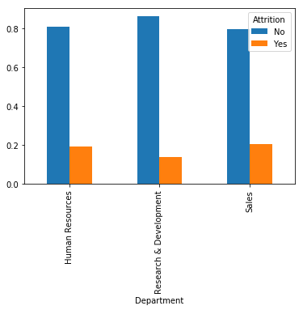

```python
# absolute numbers might not be helpful, compute percentages for each department
grouped = grouped.astype(float)
for row_index in range(3):
    total = grouped[row_index] + grouped[row_index + 3]
    grouped[row_index] /= total
    grouped[row_index + 3] /= total
grouped.unstack('Attrition').plot(kind='bar')
```

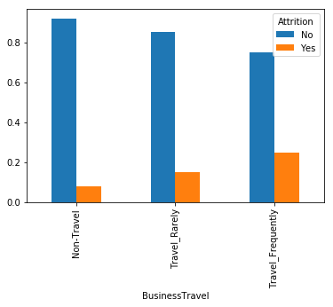

```python
# compare those that left vs those that stayed for different levels of travel
grouped = indicators[['Attrition', 'BusinessTravel']].groupby(['Attrition','BusinessTravel']).agg(pd.Series.count)
grouped = grouped.astype(float)
for row_index in range(3):
    total = grouped[row_index] + grouped[row_index + 3]
    grouped[row_index] /= total
    grouped[row_index + 3] /= total
grouped = grouped.unstack('Attrition')
grouped.reindex(index=['Non-Travel', 'Travel_Rarely', 'Travel_Frequently']).plot(kind='bar')
```

Based on the preliminary analysis, it looks like amount of travel might play a role in whether an employee stays or leaves the company. We might conduct further analysis such as calculating correlation coefficients between amount of travel and attrition to determine the strength of this relationship.

### Modeling and Predictive Analysis

If desired and possible, we might try to create mathematical models to detect trends in past data and predict future outcomes. This process can make use of statistical tools, perform a more in-depth analysis, and apply machine learning methods to better understand the data.

In this example, might try to determine what the likelihood of an employee leaving is based on amount of travel. We would probably incorporate other factors in determining the likelihood of attrition. We could validate our model using existing data and try to make predictions with our model. We might need better data to do this. If this is the case, we would work to develop a process of collecting new data.

### Communication and Visualization

Once we've done our analysis, it's important to be able to communicate the results to users. Depending on requirements, we might generate reports or create dashboards with continuously-updated data that users can rely on to inform their decision making.

Regardless of the how the information is delivered to a user, data visualizations are often used to summarize data and make the data easier to understand. While creating a chart might seem trivial, working with complex data requires certain skills to produce meaningful, easy-to-understand visualizations.

For HR, we might generate a report comparing our attrition rate with the industry. Once we better understand the factors that are likely to cause an employee to leave, we might be able to generate a dashboard for HR showing them employees who are likely to leave the company so they can be proactive.

### Feedback and Iteration

After we've completed our task, it's important to seek feedback. If our product doesn't provide what it was supposed to or is too confusing to use, it's of no use to anyone. Failure to ensure user satisfaction can lead to a company abandoning its BI effort. If improvements are necessary, the BI team must work on producing a better product.

## Sources

- [Agile Business Intelligence, How to Make it Happen?](https://www.nl.capgemini.com/resource-file-access/resource/pdf/1b-032.13_whitepaper_new_vi_agile_bi_17th_oct13_final_web_secured_1.pdf)
- [Wikipedia: Business Intelligence](https://en.wikipedia.org/wiki/Business_intelligence)
- [Wikipedia: Agile Business Intelligence](https://en.wikipedia.org/wiki/Agile_Business_Intelligence)
- [Common Business Intelligence Roles](http://knowlton-group.com/common-business-intelligence-roles/)
- [Roles and Responsibilities in Business Intelligence Teams, Part 1](http://www.b-eye-network.com/view/8137)
- [Roles and Responsibilities in Business Intelligence Teams, Part 2](http://www.b-eye-network.com/view/8360)
- [Kaggle: IBM HR Analytics Employee Attrition & Performance](https://www.kaggle.com/pavansubhasht/ibm-hr-analytics-attrition-dataset)
- [Kaggle: Human Resources Analytics](https://www.kaggle.com/ludobenistant/hr-analytics)
- Watson H. J. and Volonino L., “Harrah’s High Payoff from Customer Information”, printed in Harnessing Customer Information for Strategic Advantage: Technical Challenges and Business Solutions, W. Eckerson and H. J. Watson (Seattle: The Data Warehousing Institute, 2000) and in Teradata University Network, www.teradatauniversitynetwork.com.
- Anderson-Lehman, R., H. Watson, B. Wixom and J. Hoffer, "Continental Airlines Flies High with Real-time Business Intelligence," Teradata University Network, www.teradatauniversitynetwork.com.